# Day 2. Deal with genomic regions

by Zuguang Gu (z.gu@dkfz.de), 2017-12-13 09:01:04. The github repository for this material is at https://github.com/eilslabs/teaching.

# The GenomicRanges package

The **GenomicRanges** package provides a general `GRanges` class for storing genomic regions and related information. For gene-related regions, there are such as genes, exons, promoters. We first load the **GenomicRanges** package:

```r
library(GenomicRanges)
```

If there is error, it probably means you haven’t installed it yet. You can install the package by following commands:

```r
source("https://bioconductor.org/biocLite.R")
biocLite("GenomicRanges")
```

**GenomicRanges** is a base package for almost all Genomic data analysis. An introductory vignette can be found [here](https://bioconductor.org/packages/release/bioc/vignettes/GenomicRanges/inst/doc/GenomicRangesIntroduction.pdf).

Each genomic region (or called an interval, a range) is composed with its chromosome, a start position and an end position. An example of `GRanges` object looks like:

```r
gr = GRanges(seqnames = "chr1",
    ranges = IRanges(start = c(1000, 6000),
                     end   = c(2000, 7000))
)
gr
```

```
## GRanges object with 2 ranges and 0 metadata columns:
##       seqnames       ranges strand
##          <Rle>    <IRanges>  <Rle>
##   [1]     chr1 [1000, 2000]      *
##   [2]     chr1 [6000, 7000]      *
##   -------
##   seqinfo: 1 sequence from an unspecified genome; no seqlengths
```

## Import text files to GRanges objects

The public resources for genomic region annotations (mostly from [UCSC database](https://genome.ucsc.edu/cgi-bin/hgTables)) or other region-based annotations (e.g. SNPs, indels from international consortiums) are mainly stored as text files in table-like format. For these text files, there are always columns for chromosomes, start positions and end positions for different genomic features, thus, we can first use `read.table()` to read in to R and then use `GRanges()` function to convert to `GRanges` objects.

Following we import CpG islands annotation to `GRanges` object.

```r
## download.file("https://eilslabs.github.io/teaching/cpg_islands_hg19.bed", "cpg_islands_hg19.bed")
df = read.table("cpg_islands_hg19.bed", sep = "\t")
head(df)
```

```
##     V1     V2     V3       V4
## 1 chr1  28735  29810 CpG:_116
## 2 chr1 135124 135563  CpG:_30
## 3 chr1 327790 328229  CpG:_29
## 4 chr1 437151 438164  CpG:_84
## 5 chr1 449273 450544  CpG:_99
## 6 chr1 533219 534114  CpG:_94
```

```r
# only the first three columns are used
cgi = GRanges(seqnames = df[, 1], ranges = IRanges(df[, 2], df[, 3]))
cgi
```

```
## GRanges object with 28691 ranges and 0 metadata columns:
##                        seqnames           ranges strand
##                           <Rle>        <IRanges>  <Rle>
##       [1]                  chr1 [ 28735,  29810]      *
##       [2]                  chr1 [135124, 135563]      *
##       [3]                  chr1 [327790, 328229]      *
##       [4]                  chr1 [437151, 438164]      *
##       [5]                  chr1 [449273, 450544]      *
##       ...                   ...              ...    ...
##   [28687]  chr9_gl000201_random [ 15650,  15909]      *
##   [28688]  chr9_gl000201_random [ 26396,  26873]      *
##   [28689] chr11_gl000202_random [ 16283,  16540]      *
##   [28690] chr17_gl000204_random [ 54685,  57368]      *
##   [28691] chr17_gl000205_random [117500, 117801]      *
##   -------
##   seqinfo: 69 sequences from an unspecified genome; no seqlengths
```

## Import transcriptome annotations

There are also several standard formats for storing transcriptome annotations (e.g. where are genes, where are exons). One of the commonly used format is the GTF format. One standard transcriptome annotation is the [Gencode annotation](https://www.gencodegenes.org/releases/current.html) and they provide data download for GTF format.

A GTF format is simply a text file where gene-related annotations are stored as columns. Download a testing gencode annotation file and you can see the content of this file in your text editor:

```r
# download the file to your working directory
download.file("https://eilslabs.github.io/teaching/gencode_v19_chr21.gtf", "gencode_v19_chr21.gtf")
```

In R, there is a **GenomicFeatures** package which provides a standard way to import GTF files into R objects.

First load the **GenomicFeatures** package or install it if it is not installed yet.

```r
library(GenomicFeatures)
```

If it is not installed yet:

```r
biocLite(GenomicFeatures)
```

And use `makeTxDbFromGFF()` to import the GTF files.

```r
txdb = makeTxDbFromGFF("gencode_v19_chr21.gtf")
```

In **GenomicFeatures** package, the transcriptome data is stored as a `TxDb` object. The `TxDb` is actually an interface of a local file-based database and the package provides a lot of functions to extract gene-related annotations:

```r
genes = genes(txdb)
genes
```

```
## GRanges object with 736 ranges and 1 metadata column:
##                      seqnames               ranges strand |
##                         <Rle>            <IRanges>  <Rle> |
##    ENSG00000141956.9    chr21 [43218385, 43299591]      - |
##   ENSG00000141959.12    chr21 [45719934, 45747259]      + |
##    ENSG00000142149.4    chr21 [33245628, 33416946]      + |
##   ENSG00000142156.10    chr21 [47401651, 47424964]      + |
##    ENSG00000142166.8    chr21 [34696734, 34732168]      + |
##                  ...      ...                  ...    ... .
##    ENSG00000273210.1    chr21 [38737779, 38738234]      - |
##    ENSG00000273254.1    chr21 [30396576, 30397211]      - |
##    ENSG00000273271.1    chr21 [33039041, 33039560]      - |
##    ENSG00000273464.1    chr21 [31029726, 31030151]      + |
##    ENSG00000273492.1    chr21 [27543189, 27589700]      + |
##                                 gene_id
##                             <character>
##    ENSG00000141956.9  ENSG00000141956.9
##   ENSG00000141959.12 ENSG00000141959.12
##    ENSG00000142149.4  ENSG00000142149.4
##   ENSG00000142156.10 ENSG00000142156.10
##    ENSG00000142166.8  ENSG00000142166.8
##                  ...                ...
##    ENSG00000273210.1  ENSG00000273210.1
##    ENSG00000273254.1  ENSG00000273254.1
##    ENSG00000273271.1  ENSG00000273271.1
##    ENSG00000273464.1  ENSG00000273464.1
##    ENSG00000273492.1  ENSG00000273492.1
##   -------
##   seqinfo: 1 sequence from an unspecified genome; no seqlengths
```

```r
exons = exons(txdb)
exons
```

```
## GRanges object with 7009 ranges and 1 metadata column:
##          seqnames               ranges strand |   exon_id
##             <Rle>            <IRanges>  <Rle> | <integer>
##      [1]    chr21 [ 9683191,  9683272]      + |         1
##      [2]    chr21 [ 9825832,  9826011]      + |         2
##      [3]    chr21 [ 9826203,  9826263]      + |         3
##      [4]    chr21 [10199943, 10200025]      + |         4
##      [5]    chr21 [10385953, 10386047]      + |         5
##      ...      ...                  ...    ... .       ...
##   [7005]    chr21 [48020195, 48020288]      - |      7005
##   [7006]    chr21 [48022191, 48022329]      - |      7006
##   [7007]    chr21 [48022191, 48022806]      - |      7007
##   [7008]    chr21 [48024926, 48025121]      - |      7008
##   [7009]    chr21 [48073470, 48073934]      - |      7009
##   -------
##   seqinfo: 1 sequence from an unspecified genome; no seqlengths
```

Note in above code, a normal variable can have same name as a function name and they will not conflict because R can distinguish whether it is a variable or a function.

Since a gene can have alternative transcripts, you can get a list of `GRanges` objects where each corresponds to transcripts for a gene.

```r
gl = transcriptsBy(txdb)
gl
```

```
## GRangesList object of length 736:
## $ENSG00000141956.9
## GRanges object with 17 ranges and 2 metadata columns:
##        seqnames               ranges strand |     tx_id           tx_name
##           <Rle>            <IRanges>  <Rle> | <integer>       <character>
##    [1]    chr21 [43218385, 43230822]      - |      1852 ENST00000470586.1
##    [2]    chr21 [43218385, 43235318]      - |      1853 ENST00000486812.1
##    [3]    chr21 [43218385, 43283411]      - |      1854 ENST00000447016.2
##    [4]    chr21 [43218385, 43299582]      - |      1855 ENST00000398548.1
##    [5]    chr21 [43218385, 43299582]      - |      1856 ENST00000422911.1
##    ...      ...                  ...    ... .       ...               ...
##   [13]    chr21 [43221817, 43224883]      - |      1864 ENST00000477633.1
##   [14]    chr21 [43223054, 43240139]      - |      1865 ENST00000495217.1
##   [15]    chr21 [43241547, 43255627]      - |      1866 ENST00000491486.1
##   [16]    chr21 [43246333, 43257003]      - |      1867 ENST00000489661.1
##   [17]    chr21 [43248677, 43257041]      - |      1868 ENST00000496124.1
##
## ...
## <735 more elements>
## -------
## seqinfo: 1 sequence from an unspecified genome; no seqlengths
```

## Basic region-based manipulation

Extract TSS of genes:

```r
tss = promoters(genes, upstream = 0, downstream = 1)
tss
```

```
## GRanges object with 736 ranges and 1 metadata column:
##                      seqnames               ranges strand |
##                         <Rle>            <IRanges>  <Rle> |
##    ENSG00000141956.9    chr21 [43299591, 43299591]      - |
##   ENSG00000141959.12    chr21 [45719934, 45719934]      + |
##    ENSG00000142149.4    chr21 [33245628, 33245628]      + |
##   ENSG00000142156.10    chr21 [47401651, 47401651]      + |
##    ENSG00000142166.8    chr21 [34696734, 34696734]      + |
##                  ...      ...                  ...    ... .
##    ENSG00000273210.1    chr21 [38738234, 38738234]      - |
##    ENSG00000273254.1    chr21 [30397211, 30397211]      - |
##    ENSG00000273271.1    chr21 [33039560, 33039560]      - |
##    ENSG00000273464.1    chr21 [31029726, 31029726]      + |
##    ENSG00000273492.1    chr21 [27543189, 27543189]      + |
##                                 gene_id
##                             <character>
##    ENSG00000141956.9  ENSG00000141956.9
##   ENSG00000141959.12 ENSG00000141959.12
##    ENSG00000142149.4  ENSG00000142149.4
##   ENSG00000142156.10 ENSG00000142156.10
##    ENSG00000142166.8  ENSG00000142166.8
##                  ...                ...
##    ENSG00000273210.1  ENSG00000273210.1
##    ENSG00000273254.1  ENSG00000273254.1
##    ENSG00000273271.1  ENSG00000273271.1
##    ENSG00000273464.1  ENSG00000273464.1
##    ENSG00000273492.1  ENSG00000273492.1
##   -------
##   seqinfo: 1 sequence from an unspecified genome; no seqlengths
```

Extract promoters of genes

```r
promoters = promoters(genes, upstream = 1000, downstream = 200)
promoters
```

```
## GRanges object with 736 ranges and 1 metadata column:
##                      seqnames               ranges strand |
##                         <Rle>            <IRanges>  <Rle> |
##    ENSG00000141956.9    chr21 [43299392, 43300591]      - |
##   ENSG00000141959.12    chr21 [45718934, 45720133]      + |
##    ENSG00000142149.4    chr21 [33244628, 33245827]      + |
##   ENSG00000142156.10    chr21 [47400651, 47401850]      + |
##    ENSG00000142166.8    chr21 [34695734, 34696933]      + |
##                  ...      ...                  ...    ... .
##    ENSG00000273210.1    chr21 [38738035, 38739234]      - |
##    ENSG00000273254.1    chr21 [30397012, 30398211]      - |
##    ENSG00000273271.1    chr21 [33039361, 33040560]      - |
##    ENSG00000273464.1    chr21 [31028726, 31029925]      + |
##    ENSG00000273492.1    chr21 [27542189, 27543388]      + |
##                                 gene_id
##                             <character>
##    ENSG00000141956.9  ENSG00000141956.9
##   ENSG00000141959.12 ENSG00000141959.12
##    ENSG00000142149.4  ENSG00000142149.4
##   ENSG00000142156.10 ENSG00000142156.10
##    ENSG00000142166.8  ENSG00000142166.8
##                  ...                ...
##    ENSG00000273210.1  ENSG00000273210.1
##    ENSG00000273254.1  ENSG00000273254.1
##    ENSG00000273271.1  ENSG00000273271.1
##    ENSG00000273464.1  ENSG00000273464.1
##    ENSG00000273492.1  ENSG00000273492.1
##   -------
##   seqinfo: 1 sequence from an unspecified genome; no seqlengths
```

Extract intergenic regions. Since genes have strand information while intergenic regions do not, we need first to remove the strand information.

```r
g2 = genes
strand(g2) = "*" # there are three possible values for strand, "*" means no strand information
intergenic = gaps(g2)
```

The gene annotation in Gencode is actually the union of all its transcripts. We can test it with the first gene in chromosome 21:

```r
# all transcript for the first gene on chromosome 21
gl[[1]]
```

```
## GRanges object with 17 ranges and 2 metadata columns:
##        seqnames               ranges strand |     tx_id           tx_name
##           <Rle>            <IRanges>  <Rle> | <integer>       <character>
##    [1]    chr21 [43218385, 43230822]      - |      1852 ENST00000470586.1
##    [2]    chr21 [43218385, 43235318]      - |      1853 ENST00000486812.1
##    [3]    chr21 [43218385, 43283411]      - |      1854 ENST00000447016.2
##    [4]    chr21 [43218385, 43299582]      - |      1855 ENST00000398548.1
##    [5]    chr21 [43218385, 43299582]      - |      1856 ENST00000422911.1
##    ...      ...                  ...    ... .       ...               ...
##   [13]    chr21 [43221817, 43224883]      - |      1864 ENST00000477633.1
##   [14]    chr21 [43223054, 43240139]      - |      1865 ENST00000495217.1
##   [15]    chr21 [43241547, 43255627]      - |      1866 ENST00000491486.1
##   [16]    chr21 [43246333, 43257003]      - |      1867 ENST00000489661.1
##   [17]    chr21 [43248677, 43257041]      - |      1868 ENST00000496124.1
##   -------
##   seqinfo: 1 sequence from an unspecified genome; no seqlengths
```

```r
# take the union of all its transcripts:
reduce(gl[[1]])
```

```
## GRanges object with 1 range and 0 metadata columns:
##       seqnames               ranges strand
##          <Rle>            <IRanges>  <Rle>
##   [1]    chr21 [43218385, 43299591]      -
##   -------
##   seqinfo: 1 sequence from an unspecified genome; no seqlengths
```

```r
# and compare to the gene annotation in `genes` variable
genes[1]
```

```
## GRanges object with 1 range and 1 metadata column:
##                     seqnames               ranges strand |
##                        <Rle>            <IRanges>  <Rle> |
##   ENSG00000141956.9    chr21 [43218385, 43299591]      - |
##                               gene_id
##                           <character>
##   ENSG00000141956.9 ENSG00000141956.9
##   -------
##   seqinfo: 1 sequence from an unspecified genome; no seqlengths
```

## Set operations on genomic regions

Set operations relate to how to associate two different types of genomic annotations. In following example, we associate or annotate CpG islands to gene promoters.

We look for which promoters overlap to CpG islands. Here we use `findOverlaps()` function to do intersection between two sets of regions:

```r
mtch = findOverlaps(cgi, promoters)
mtch
```

```
## Hits object with 177 hits and 0 metadata columns:
##         queryHits subjectHits
##         <integer>   <integer>
##     [1]     26639         676
##     [2]     26639         678
##     [3]     26645         193
##     [4]     26651         325
##     [5]     26655         704
##     ...       ...         ...
##   [173]     26980         103
##   [174]     26981         102
##   [175]     26981         103
##   [176]     26993         104
##   [177]     26996         106
##   -------
##   queryLength: 28691 / subjectLength: 736
```

`mtch` contains two columns where e.g. the first row means the 26639^th row in `cgi` overlaps to row 676^th in `promoters`.

Normally we don’t directly use `mtch`, we convert it to a matrix and later we can use the indices in the two columns:

```r
mtch = as.matrix(mtch)
head(mtch)
```

```
##      queryHits subjectHits
## [1,]     26639         676
## [2,]     26639         678
## [3,]     26645         193
## [4,]     26651         325
## [5,]     26655         704
## [6,]     26659         427
```

With the correspondance between the two columns of indices, we can extract those promoters overlapping to Cpg islands:

```r
cgi_promoters = promoters[unique(mtch[, 2])]
cgi_promoters
```

```
## GRanges object with 169 ranges and 1 metadata column:
##                      seqnames               ranges strand |
##                         <Rle>            <IRanges>  <Rle> |
##    ENSG00000264063.1    chr21 [ 9825203,  9826402]      + |
##    ENSG00000264462.1    chr21 [ 9824832,  9826031]      + |
##    ENSG00000188681.7    chr21 [ 9968386,  9969585]      - |
##    ENSG00000224309.3    chr21 [14409481, 14410680]      + |
##    ENSG00000269011.1    chr21 [15053260, 15054459]      - |
##                  ...      ...                  ...    ... .
##    ENSG00000182362.9    chr21 [47705251, 47706450]      + |
##   ENSG00000160299.12    chr21 [47743036, 47744235]      + |
##   ENSG00000160298.13    chr21 [47743590, 47744789]      - |
##   ENSG00000160305.13    chr21 [47877812, 47879011]      + |
##   ENSG00000160310.12    chr21 [48054079, 48055278]      + |
##                                 gene_id
##                             <character>
##    ENSG00000264063.1  ENSG00000264063.1
##    ENSG00000264462.1  ENSG00000264462.1
##    ENSG00000188681.7  ENSG00000188681.7
##    ENSG00000224309.3  ENSG00000224309.3
##    ENSG00000269011.1  ENSG00000269011.1
##                  ...                ...
##    ENSG00000182362.9  ENSG00000182362.9
##   ENSG00000160299.12 ENSG00000160299.12
##   ENSG00000160298.13 ENSG00000160298.13
##   ENSG00000160305.13 ENSG00000160305.13
##   ENSG00000160310.12 ENSG00000160310.12
##   -------
##   seqinfo: 1 sequence from an unspecified genome; no seqlengths
```

## Distance-based annotation

Another commonly used annotation is to look for nearest genomic features, e.g. nearest genes. Since we only have transcriptome information on chromosome 21, we also subset `cgi` to chromosome 21:

```r
cgi_chr21 = cgi[seqnames(cgi) == "chr21"]
nst = distanceToNearest(cgi_chr21, tss)
nst
```

```
## Hits object with 365 hits and 1 metadata column:
##         queryHits subjectHits |  distance
##         <integer>   <integer> | <integer>
##     [1]         1         601 |    243717
##     [2]         2         601 |    198527
##     [3]         3         601 |     35074
##     [4]         4         601 |     25743
##     [5]         5         678 |         0
##     ...       ...         ... .       ...
##   [361]       361         105 |      6329
##   [362]       362         106 |       119
##   [363]       363         454 |      5125
##   [364]       364         454 |      7306
##   [365]       365         454 |     13265
##   -------
##   queryLength: 365 / subjectLength: 736
```

`nst` has a table-like structure which contains the indices of nearest tss for each CpG island as well as the distance itself. To extract these information, we first convert it to a data frame:

```r
nst = as.data.frame(nst)
head(nst)
```

```
##   queryHits subjectHits distance
## 1         1         601   243717
## 2         2         601   198527
## 3         3         601    35074
## 4         4         601    25743
## 5         5         678        0
## 6         6         611    28558
```

And associations are added to `cgi_chr21` as additional data columns.

```r
cgi_chr21$near_tss_gene = names(tss)[nst$subjectHits]
cgi_chr21$dist_to_nearest_tss = nst$distance
cgi_chr21
```

```
## GRanges object with 365 ranges and 2 metadata columns:
##         seqnames               ranges strand |      near_tss_gene
##            <Rle>            <IRanges>  <Rle> |        <character>
##     [1]    chr21   [9437272, 9439473]      * |  ENSG00000238411.1
##     [2]    chr21   [9483485, 9484663]      * |  ENSG00000238411.1
##     [3]    chr21   [9647866, 9648116]      * |  ENSG00000238411.1
##     [4]    chr21   [9708935, 9709231]      * |  ENSG00000238411.1
##     [5]    chr21   [9825442, 9826296]      * |  ENSG00000264462.1
##     ...      ...                  ...    ... .                ...
##   [361]    chr21 [48018542, 48018791]      * |  ENSG00000160307.5
##   [362]    chr21 [48055199, 48056060]      * | ENSG00000160310.12
##   [363]    chr21 [48068517, 48068808]      * |  ENSG00000230982.1
##   [364]    chr21 [48081241, 48081849]      * |  ENSG00000230982.1
##   [365]    chr21 [48087200, 48088106]      * |  ENSG00000230982.1
##         dist_to_nearest_tss
##                   <integer>
##     [1]              243717
##     [2]              198527
##     [3]               35074
##     [4]               25743
##     [5]                   0
##     ...                 ...
##   [361]                6329
##   [362]                 119
##   [363]                5125
##   [364]                7306
##   [365]               13265
##   -------
##   seqinfo: 69 sequences from an unspecified genome; no seqlengths
```

Now let’s look at the distribution of the distance:

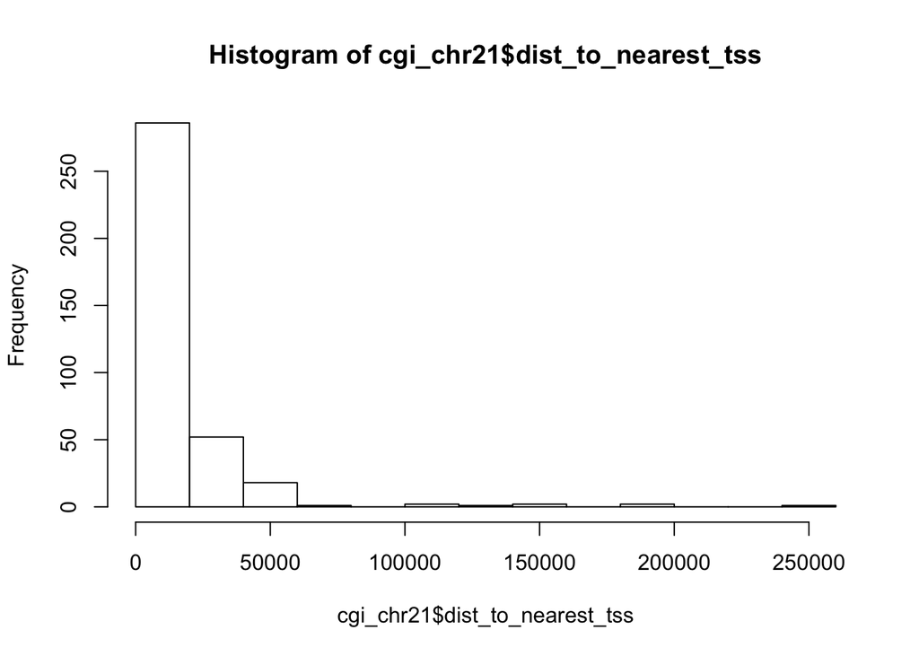

```r
hist(cgi_chr21$dist_to_nearest_tss)
```

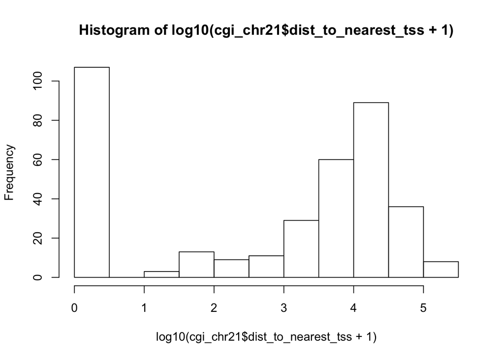

```r
hist(log10(cgi_chr21$dist_to_nearest_tss+1))
```

After log10-transformation of the distance, we found there are two groups of CpG islands where one overlaps to tss and the other is far from TSS (mean distance ~ 10kb).

# Exercise

### task

There is a statistic called the Jaccard coefficient which measures how two sets of regions correlate. If we denote set 1 as $S_1$ and set 2 as $S_2$, the Jaccard coefficient is defined as:

$$Jaccard = \frac {\bigcap(S_1, S_2)}{\bigcup(S_1, S_2)}$$

Please implement code to calculate the Jaccard coefficient between CpG island and promoters/exons/intergenic regions.

Hint: to calculate the intersection of $S_1$ and $S_2$, use `intersect()` function. To calculate the union of $S_1$ and $S_2$, use `union()` function. To calculate the “size” of the set, use `sum(width(...))` function which is the total width of the regions in the set.

### solution

```r
j1 = sum(width(intersect(cgi_chr21, promoters, ignore.strand = TRUE))) /
     sum(width(union(cgi_chr21, promoters, ignore.strand = TRUE)))
j1
```

```
## [1] 0.07954224
```

```r
j2 = sum(width(intersect(cgi_chr21, exons, ignore.strand = TRUE))) /
     sum(width(union(cgi_chr21, exons, ignore.strand = TRUE)))
j2
```

```
## [1] 0.05792093
```

```r
j3 = sum(width(intersect(cgi_chr21, intergenic))) /
     sum(width(union(cgi_chr21, intergenic)))
j3
```

```
## [1] 0.002363584
```

With the Jaccard coefficient, we can make the conclusion that CpG island is more associated to promoters/exons while less associated to intergenic regions.